# 2019 Seed Financial Planning

Sean Davern

June 5, 2019

# Import of Data

The original data was provided by John Earling in a work book entitled ‘Weekly PayPay & Tithes .xls’ workbook. The layout/format of that workbook was not conducive to easily loading into R [nor JMP originally] and so was transcribed into the workbook ‘Giving Data.xlsx’ and then read into R.

```r
source("../code/0-Extract data from Excel.R")
df  # This is the data frame resulting from the import.
```

| week.ending | month | year | paypal | offering | total | monthly.giving.families |
| --- | --- | --- | --- | --- | --- | --- |
| 2010-01-03 | January | 2010 | 75.00 | 1560.00 | 1635.00 | NA |
| 2010-01-10 | January | 2010 | 575.00 | 3129.00 | 3704.00 | NA |
| 2010-01-17 | January | 2010 | 475.00 | 2025.00 | 2500.00 | NA |
| 2010-01-24 | January | 2010 | 75.00 | 1180.05 | 1255.05 | NA |
| 2010-01-31 | January | 2010 | 2180.00 | 2967.10 | 5147.10 | 45 |
| 2010-02-07 | February | 2010 | 75.00 | 4722.50 | 4797.50 | NA |
| 2010-02-14 | February | 2010 | 585.00 | 2925.00 | 3510.00 | NA |
| 2010-02-21 | February | 2010 | 200.00 | 3299.00 | 3499.00 | NA |
| 2010-02-28 | February | 2010 | 6350.00 | 4281.00 | 10631.00 | 41 |
| 2010-03-07 | March | 2010 | 770.00 | 1170.00 | 1940.00 | NA |

[output cut: 459 more lines]

# Some Minor Data Validation

As a first validation I’ll check that the weekly PayPal and offering amounts sum to the weekly totals $(paypal_i+{offering}_i\overset{?}=total_i)$, reporting only those that aren’t equal:

```r
source("../code/1-Validate totals.R")
```

```
***** WARNING *****
Some 'total' observations don't equal the sum of 'paypal' and 'offering'!
```

| week.ending | month | year | paypal | offering | total | calcd.total | diff |
| --- | --- | --- | --- | --- | --- | --- | --- |
| 2015-12-27 | December | 2015 | 1902 | 9306 | 16958 | 11208 | 5750 |
| 2016-12-25 | December | 2016 | 4635 | 10089 | 22849 | 14724 | 8125 |
| 2017-04-23 | April | 2017 | 635 | 4480 | 4615 | 5115 | -500 |

Ok, so December 2015 and 2016 seem to have totals greater than accounted for by the PayPal and offering amounts. That’s perhaps explainable by other end-of-year giving coming in another way. However, the April 2017 discrepancy seems to be missing $500. I’ll need to look into that.

# Data Transformation

Aggregating the monthly totals and preparing to model month values…

```r
# Data transformation: Calculate monthly giving totals.
# Make Month a categorical variable with levels in the order that
# months occur in the year otherwise months are sorted alphabetically.
df$month <- factor(df$month, month.name)
# Aggregate the monthly Totals from giving.data in sums for each month.
MonthTotals <-
  aggregate(df$total, by = list(df$month, df$year), FUN = sum)
# Exclude the months that don't have totals yet.
MonthTotals <- MonthTotals[complete.cases(MonthTotals), ]
# Extract only rows containing 'monthly.giving.families' data.
df <- df[!is.na(df$monthly.giving.families),]
# Now replace Totals (which were weekly totals) with calculated aggregates
df$total <- MonthTotals$x
# paypal & offering columns are now misleading (only week's value) so remove them.
df <- select(df, -paypal, -offering)
```

Adding the number of giving Sundays in the month and the average giving each week per month…

```r
source("../code/NumOfGivenDayOfWeekInMonth.R")
# Calculate and add the columns SundaysInMonth with calculated values
# and MonthsGivingPerWeek
df <-  df %>%
  mutate(SundaysInMonth =
           NumOfGivenDayOfWeekInMonth(df$week.ending, "Sunday")) %>%
  mutate(MonthsGivingPerWeek = total / SundaysInMonth)
```

Enable modeling year as factor…

```r
# Make year a categorical variable so coefficients are easier to interpret.
df$year <- as.factor(df$year)
```

Save the resulting tibble:

```r
# Code chunk eval=false so files don't get overwritten willy nilly.
# Write it as a csv:
write.csv(x = df,
          file = "../data/Cleaned and Transformed Giving Data.csv",
          row.names = FALSE)
# Save it as an R object that can be loaded into a new R object.
saveRDS(df, file = "../data/Cleaned and Transformed Giving Data.rds")
```

# Replicating Previous Modeling

```r
# Pair the data down to that used in the original analysis
df2 <- df[df$week.ending > "2010-01-01" & df$week.ending < "2013-07-31",] %>%
  mutate(excluded = FALSE)
df2$excluded[as.Date(df2$week.ending) == "2010-02-28"] <- TRUE
df2$excluded[as.Date(df2$week.ending) == "2012-04-29"] <- TRUE
df2$excluded[as.Date(df2$week.ending) == "2012-12-30"] <- TRUE
# Regress the model
mod <- lm(
  formula = total ~
    year + month,
  data = df2[df2$excluded!=TRUE,]
)
```

Which gives the resulting model fit:

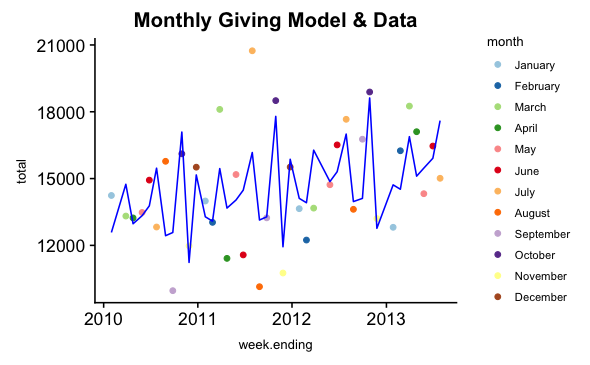

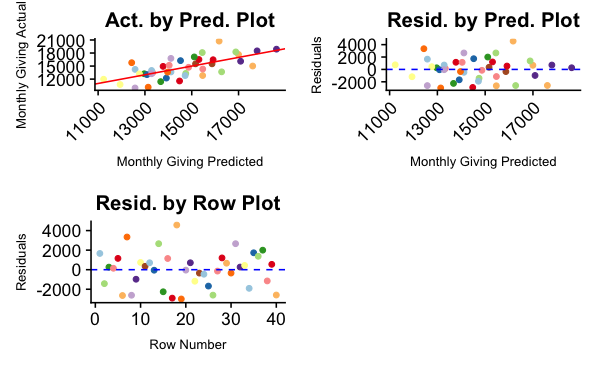

# References

Davern, Sean. 2013. “An Assessment of Requested Seed Core Support Ofr Expansion Based on Analysis of Giving.” *Internal Report*, August. file://../Reports/August%202013%20Analysis%20of%20Giving.pdf.